# Framing the concept of satellite remote sensing essential biodiversity variables: challenges and future directions - Pettorelli - 2016 - Remote Sensing in Ecology and Conservation - Wiley Online Libra

[figure not shown]

Policy Forum

Open Access

# Framing the concept of satellite remote sensing essential biodiversity variables: challenges and future directions

[Nathalie Pettorelli](https://zslpublications.onlinelibrary.wiley.com/action/doSearch?ContribAuthorStored=Pettorelli%2C+Nathalie)

[Martin Wegmann](https://zslpublications.onlinelibrary.wiley.com/action/doSearch?ContribAuthorStored=Wegmann%2C+Martin)

[Andrew Skidmore](https://zslpublications.onlinelibrary.wiley.com/action/doSearch?ContribAuthorStored=Skidmore%2C+Andrew)

[Sander Mücher](https://zslpublications.onlinelibrary.wiley.com/action/doSearch?ContribAuthorStored=M%C3%BCcher%2C+Sander)

[Terence P. Dawson](https://zslpublications.onlinelibrary.wiley.com/action/doSearch?ContribAuthorStored=Dawson%2C+Terence+P)

[Miguel Fernandez](https://zslpublications.onlinelibrary.wiley.com/action/doSearch?ContribAuthorStored=Fernandez%2C+Miguel)

[Richard Lucas](https://zslpublications.onlinelibrary.wiley.com/action/doSearch?ContribAuthorStored=Lucas%2C+Richard)

[Michael E. Schaepman](https://zslpublications.onlinelibrary.wiley.com/action/doSearch?ContribAuthorStored=Schaepman%2C+Michael+E)

[Tiejun Wang](https://zslpublications.onlinelibrary.wiley.com/action/doSearch?ContribAuthorStored=Wang%2C+Tiejun)

[Brian O'Connor](https://zslpublications.onlinelibrary.wiley.com/action/doSearch?ContribAuthorStored=O%27Connor%2C+Brian)

First published: 25 March 2016

https://doi.org/10.1002/rse2.15

Citations: 132

## Abstract

Although satellite‐based variables have for long been expected to be key components to a unified and global biodiversity monitoring strategy, a definitive and agreed list of these variables still remains elusive. The growth of interest in biodiversity variables observable from space has been partly underpinned by the development of the essential biodiversity variable (EBV) framework by the Group on Earth Observations – Biodiversity Observation Network, which itself was guided by the process of identifying essential climate variables. This contribution aims to advance the development of a global biodiversity monitoring strategy by updating the previously published definition of EBV, providing a definition of satellite remote sensing (SRS) EBVs and introducing a set of principles that are believed to be necessary if ecologists and space agencies are to agree on a list of EBVs that can be routinely monitored from space. Progress toward the identification of SRS‐EBVs will require a clear understanding of what makes a biodiversity variable essential, as well as agreement on who the users of the SRS‐EBVs are. Technological and algorithmic developments are rapidly expanding the set of opportunities for SRS in monitoring biodiversity, and so the list of SRS‐EBVs is likely to evolve over time. This means that a clear and common platform for data providers, ecologists, environmental managers, policy makers and remote sensing experts to interact and share ideas needs to be identified to support long‐term coordinated actions.

## Introduction

In 1988, James Hansen famously stated to a United States Senate panel that human‐caused warming had already measurably affected the global climate (The New York Times 1988). Four years after this key statement, the Global Climate Observing System was established to ensure that the observations and information needed to address climate‐related issues are collected and distributed to all potential users. One of the many achievements of the Global Climate Observing System has been the identification of 50 essential climate variables, defined as the set of observations needed for generating and updating global climate products and derived information (Bojinski et al. 2014). Essential climate variables were identified on the premise that they must be feasible for global climate observations as well as strongly support the requirements of the United Nations Framework Convention on Climate Change and other stakeholders (e.g. the Intergovernmental Panel on Climate Change). Thanks to this identification, society has made tremendous progress in its ability to understand and predict climate change.

There is little doubt, nowadays, that the current biodiversity crisis is comparable to (some would argue is even exceeding) the climate change crisis, in terms of its potential to impact human well‐being (Steffen et al. 2015). For example, it has been recently estimated that out of the conservatively estimated 5–9 million animal species inhabiting the planet, ~11,000–58,000 species are lost annually (Dirzo et al. 2014). The latest Living Planet report, moreover, highlighted how global wildlife populations have declined by 52% in abundance over the past 40 years (Living Planet Report 2014). At the same time, evidence on the role of biodiversity in supporting the functioning of ecosystems, economies and human health continues to mount (Cardinale et al. 2012); the recent decline in pollinators and its potential impact on food production being a key example of this issue (Klein et al. 2007).

Various mechanisms put in place in the past decades to address biodiversity loss are comparable to those implemented in response to climate change. For example, both the United Nations Framework Convention on Climate Change and the Convention on Biological Diversity were opened for signature in 1992; the ideas underpinning the creation of the Intergovernmental Science‐Policy Platform on Biodiversity and Ecosystem Services are also very similar to the ones that led to the formation of the Intergovernmental Panel on Climate Change. To date, however, the biodiversity community still lacks a global observing system that revolves around the monitoring of a set of agreed variables essential to the tracking of changes in biological diversity on Earth. Such a gap is worrying, as operational systems of this kind and the associated identification of priority variables to be monitored are key to (1) coordinating globally consistent data collection across all dimensions of biodiversity, (2) minimizing duplication of efforts so that conservation funds are not wasted, and (3) optimizing the allocation of the limited funds available for biodiversity monitoring worldwide.

Progress to fill this currently empty space has been made in the past 10 years. The Group on Earth Observations – Biodiversity Observation Network (GEO BON) was launched in 2008, and the hope is that GEO BON will eventually coordinate a functioning global biodiversity observing system. In 2012, a GEO BON workshop developed the basic concept of essential biodiversity variables (EBVs) and proposed an initial list of candidates (Pereira et al. 2013). Several EBVs are anticipated to be derived from satellite remote sensing (SRS), because SRS is the only methodology able to provide a global coverage and continuous measures across space at relatively high spatial and temporal resolutions (Skidmore et al. 2015). However, so far the scientific community has still not reached an agreement on how EBVs should be defined, and what these EBVs should be.

Looking through a policy lens, we here propose a refinement of the current definition of EBVs and a framework for identifying EBVs to which SRS can contribute. This framework aims to facilitate the integration of both remote sensing and biodiversity monitoring needs while detailing the pathways from data collection to the generation of SRS‐EBVs. Importantly, this contribution goes beyond reiterating that satellites offer increasingly broader opportunities in natural resource management and conservation, and capitalizes on the experience of a diverse group of authors to discuss the policy context required for the identification and implementation of SRS‐EBVs to be successful. The piece concludes by highlighting the importance and challenges associated with the development of a unified view on monitoring needs, for the benefit of biodiversity conservation.

## Refining the Definition of EBVs

### EBVs: the current state of play

Biodiversity is defined by the Convention on Biological Diversity as ‘the variability among living organisms from all sources including diversity within species, between species and of ecosystems’ (Convention on Biological Diversity 1992). It can be measured in terms of different components (genetic, population/species, community/ecosystem; Davies et al. 2013), each of which possesses compositional, structural and functional attributes; these are often considered to be the ‘three dimensions’ of biodiversity (Noss 1990). Given the fundamentally multidimensional nature of biodiversity (Lyashevska and Farnsworth 2012), comprehensive monitoring to capture all of its elements is challenging (Davies et al. 2013). Any attempt to define a set of variables for tracking biodiversity change should indeed ensure that information on all components and dimensions of biodiversity are being captured.

The concept of EBVs was originally developed at the request of the Convention on Biological Diversity, following a workshop in Wageningen in December 2011 (Robert Jongman, *Pers. Comm*.). Following multiple discussions across varied groups of stakeholders, EBVs were defined as measurements required for studying, reporting and managing biodiversity change (Pereira et al. 2013). Six classes of EBVs were distinguished: genetic composition, species populations, species traits, community composition, ecosystem structure and ecosystem functions. These classes are a clear attempt to capture the various organizational dimensions of biodiversity when identifying EBVs. EBVs, as originally described by Pereira et al. (2013), possess a set of characteristics, which include (1) sensitivity to change over time; (2) a focus on ‘state’ variables (as per the ‘Pressure State Response’ framework routinely used by the Convention on Biological Diversity; Sparks et al. 2011) and (3) generally falling between low‐level (primary) observations and high‐level indicators of biodiversity change. Other important characteristics included scalability, technical and economic feasibility for global implementation and usefulness for informing progress toward the Convention on Biological Diversity targets (Pereira et al. 2013).

Much progress has been made in our understanding of the EBV concept since Pereira et al. (2013), and some important refinements can now be made. Specifically, Pereira et al. were vague about who would be the users of EBVs and which of their needs EBVs would help to fulfill. These are yet crucial because different communities have different requirements and thus different considerations as to what makes a biodiversity variable ‘essential’. In contrast, essential climate variables had more clearly defined users and targeted specific needs to help understand and predict the evolution of climate (Bojinski et al. 2014). Without a clear understanding of the users and their needs it is not possible to identify and prioritize a finite set of EBVs.

### Moving forward with the definition of EBVs

With the above in mind, we suggest that, similarly to essential climate variables strongly supporting the requirements of the United Nations Framework Convention on Climate Change and the Intergovernmental Panel on Climate Change, EBVs are variables required to primarily support the work of the Convention on Biological Diversity and the Intergovernmental Science‐Policy Platform on Biodiversity and Ecosystem Services. We, however, acknowledge that EBVs can also benefit other initiatives and conventions. Given that EBVs are variables for monitoring the state of biodiversity and its change over time, then (1) EBV users are the scientists involved with advancing our understanding of changes in biodiversity on behalf of the Convention on Biological Diversity and the Intergovernmental Science‐Policy Platform on Biodiversity and Ecosystem Services, and (2) a tighter definition of EBV that captures this commitment to these users and articulates the criteria associated with the ‘essential’ denomination is needed. We therefore propose the following updated definition of EBV, which is inspired by the recent review by Bojinski et al. (2014) and based on the considerable knowledge gained and work done since Pereira et al. (2013):

> An EBV is a variable or a group of linked variables that allows quantification of the rate and direction of change in one aspect of the state of biodiversity over time and across space. An EBV is critical for understanding and predicting changes in the most integrated and established global indicators of biodiversity. The following requirements should be fulfilled: EBVs are sensitive to changes; observing or deriving EBVs on a global scale is technically feasible using standardised, proven methods; generating and archiving EBV data is also affordable, mainly relying on coordinated observing systems using proven technologies, taking advantage, where possible, of historical datasets.

There are several global biodiversity indicators currently recognized by the Convention on Biological Diversity as providing information on the state of biodiversity. The most integrated and established one is the Red List Index (Butchart et al. 2005), which relies on assessing the extinction risk of species (Mace et al. 2008) and potentially, of ecosystems (Rodríguez et al. 2015). The Red List Index is partly made possible through the availability of data on species abundances and distributions; these variables have already been listed as potential EBVs (Pereira et al. 2013). Predictive modeling on both the International Union for Conservation of Nature Red List of Threatened Species (see e.g. Thuiller et al. 2005; Safi and Pettorelli 2010; Di Marco et al. 2013) and the Red List Index (Visconti et al. 2015) has been shown to be possible.

### Differences between EBVs and biodiversity indicators

Given that the proposed definition makes use of the hierarchical approach detailed in Pereira et al. (2013), whereby EBVs are the entities underpinning the generation of biodiversity indicators, it becomes important to clarify the differences between EBVs and biodiversity indicators. Biodiversity indicators are defined by the International Union for the Conservation of Nature as measures of biodiversity that help scientists, managers and politicians understand the condition of biodiversity and the factors that affect it (International Union for the Conservation of Nature 2015). The development of biodiversity indicators is promoted and coordinated by the Biodiversity Indicators Partnership, which is mandated by the Convention on Biological Diversity. A main difference between EBVs and biodiversity indicators is that EBVs have been conceptualized as state variables containing the information needed for the generation of biodiversity indicators that focus on the state of biodiversity. Biodiversity indicators thus target a higher level of abstraction than EBVs and are designed to appeal to a wider, less technical audience (Pereira et al. 2013).

Criteria for variables that qualify as global biodiversity indicators are being discussed (Tittensor et al. 2014). Based on these recent discussions, other differences between biodiversity indicators and EBVs may include (1) current biodiversity indicators, as opposed to EBVs, must be highly relevant to a particular Aichi Target (Aichi targets representing a set of 20 global targets under the Strategic Plan for Biodiversity 2011–2020 drawn by the Convention on Biological Diversity); (2) biodiversity indicators are not systematically expected to be technically feasible and economically viable for global implementation (i.e. global coverage is not a requirement) and (3) biodiversity indicator time series should encompass at least five data points per indicator (Tittensor et al. 2014).

Another important difference between EBVs and biodiversity indicators is the fact that variables providing information on a given threat (or pressure) to biodiversity, or on society's response to changes in biodiversity, cannot be an EBV, but can become a biodiversity indicator. Confusion can arise on this issue, as (1) some pressures are themselves integral components of biodiversity, such as emerging infectious diseases and invasive alien species, and (2) variables that capture information on the occurrence and strength of certain disturbances (such as fire and floods) can be considered as both potential pressure indicators and EBVs. Indeed, in some situations, disturbances such as fire and floods can be key to the persistence of certain species (Pickett 1980); disturbance attenuation is also a recognized ecosystem function (De Groot et al. 2002) and so changes in a given disturbance regime can be indicative of a change in ecosystem functioning (Moore et al. 2009). At the same time, anthropogenic activities can lead to increased severity and occurrence of certain disturbances, and these consequences can have negative impacts on biodiversity. Currently it is not possible to globally distinguish fires or floods with clear anthropogenic attribution, which is partly why disturbances such as fire and floods can both be considered as potential EBVs and pressure indicators. Based on these examples, it appears that to facilitate EBV identification and to be able to articulate how specific EBVs relate to specific biodiversity indicators, clearer definitions of what is being understood by ‘pressures’ and ‘state’ are required.

## EBVs and SRS‐EBVs: Conciliating Agendas, Perceptions and Terminologies

### What are SRS‐EBVs?

SRS‐EBVs are here defined as the subset of EBVs whose monitoring relies largely or wholly on the use of satellite‐based data. Thus, potential SRS‐EBVs do include variables for which monitoring relies on the integration of measurements from sensors on‐board satellites with in situ and air‐borne observations, simulations and models, and classification protocols (such as land cover; Fig. 1). There is a plethora of methodologies falling under the term ‘remote sensing’ (Pettorelli et al. 2014a): we intentionally reduce the scope of SRS‐EBVs to EBVs whose monitoring involves the use of satellite sensor data (or remote sensing approaches for which satellite systems are planned in the foreseeable future; e.g. LiDAR). This is because SRS is the only form of remote sensing that can provide global coverage on a regular basis.

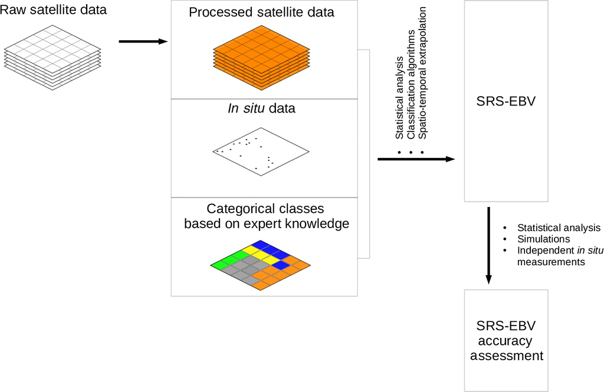

**Figure 1**

Pathways to satellite remote sensing (SRS) essential biodiversity variable (EBV) generation. Raw satellite data always require some levels of processing to correct for bias (associated for example with the sun position or geo‐referencing issues). Calibrated satellite measurements are then combined with in situ measurements, simulations and/or statistical analyses to derive potential continuous SRS‐EBVs. In the case of data gaps, spatio‐temporal extrapolation algorithms may be used to generate the global SRS‐EBV dataset. Categorical SRS‐EBVs will require expert knowledge to decide on the number of classes to be contrasted. Expert opinion is thus only thought for certain types of potential SRS‐EBV, such as land cover. Categorical SRS‐EBVs will then be generated by combining this knowledge with in situ measurements and classification algorithms. Importantly, SRS‐EBVs, once generated, will need to be validated and their accuracy assessed, using an independent dataset of in situ measurements, intra‐model comparisons and/or simulations.

A difference needs to be made between the SRS‐EBVs and the satellite measurements that may need to be used to generate these SRS‐EBVs (Fig. 1). Understandably, there is interest among space agencies to identify the set of satellite‐based measurements relevant to biodiversity monitoring and this interest can sometimes generate confusion when discussing SRS‐EBV identification. To reduce confusion, these discussions need to be treated separately and possibly hierarchically, with the identification of SRS‐EBVs preceding, or running in parallel to, the identification of satellite‐based measurements relevant to the generation of some of these SRS‐EBVs.

### Identifying SRS‐EBVs: challenges and ways forward

#### Continuous versus categorical

Vegetation height, canopy cover, greenness phenology, and leaf area index are all variables suggested as potential continuous EBVs (Skidmore et al. 2015) that can be derived from known linear or non‐linear relationships between raw satellite data and the parameter of interest. Land cover, another suggested potential SRS‐EBV (Skidmore et al. 2015), is a discretization of continuous satellite‐based measurements into land cover categories. This conversion implies defining the land cover categories to be monitored, and then in situ data representative of these categories to be collected and coupled with satellite‐based measurements using classification algorithms. History has shown that agreement on standards for the definition of land cover categories and the boundaries between these categories is difficult to reach and maintain over time (Hansen and Loveland 2012). This lack of agreement, as well as difficulties associated with the processing of an extremely high volume of data, are some of the reasons for the relative lack of comparable global land cover products required for land cover change assessments (Gross et al. 2013; but see ESA (2015) and Chen et al. (2015), for examples of global land cover products).

Heterogeneity within land cover classes can be high, and the accuracy of land cover maps derived from satellite data can, correspondingly, be quite variable (see, e.g. Herold et al. 2008). Because certain potential continuous SRS‐EBVs may require a lower level of processing and user input than other potential categorical SRS‐EBVs, and may be sometimes associated with higher accuracy, there could be temptation to prioritize potential SRS‐EBVs according to the level of processing and input required. Interestingly, no differentiation between continuous and categorical variables was considered when identifying essential climate variables, and the current list of essential climate variables is composed of continuous and categorical variables that require a variable level of user input, data combination and processing [e.g. land cover (including vegetation type), fraction of absorbed photosynthetically active radiation, leaf area index, and above‐ground biomass are all essential climate variables]. Essential climate variables were extremely successful in helping prioritize monitoring needs for climate change tracking, because discussions focused on user needs, and not on variable types. It therefore seems reasonable to adopt the same philosophy for SRS‐EBVs, which means avoiding differentiating variables based on the level of processing and input required, while focusing discussions on what information is needed most and what associated accuracy levels are acceptable for the sustainable management of biodiversity.

#### Scale and resolution dependency

Satellite sensors record information at fixed spatial, temporal and spectral resolutions. These resolutions are not consistent from one sensor to another. Importantly, these different resolutions are each associated with particular challenges and assumptions, in terms of how they can be used to monitor biodiversity. Satellite missions also cover different time periods, meaning that some satellite data started to be collected in the 1970s and 1980s, while other data only started to be collected after 2000. These heterogeneities could result in discrepancies in EBVs, in terms of baseline information, spatio‐temporal resolution and accuracy. Combining information from various sensors could offer a way to reduce some of these discrepancies in the long term, providing that relevant data access is guaranteed and that sufficient expertise and computing power are made available (Ehler 1991; Gamba and Chanussot 2008).

#### SRS‐EBVs implementation

Raw satellite measurements, pre‐processed datasets and some higher level products are distributed by space agencies and commercial companies, sometimes at no cost, sometimes for a fee. However, it is unclear at this stage who will take responsibility for (1) developing the methodology required to generate an identified SRS‐EBV; (2) producing and maintaining production of the set of intermediary global products needed to generate a final SRS‐EBV and (3) producing and maintaining the production of the final SRS‐EBVs. Space agencies collaborate under the auspices of the Committee on Earth Observation Satellites – the international coordination body for civil space‐based Earth observation programs – to produce the Climate Data Records from which satellite‐based ECVs are derived. The Committee on Earth Observation Satellites also supports the Earth observation needs of the Group on Earth Observations activities. Thus, collaboration between GEO BON and the Committee on Earth Observation Satellites could enable assessment of existing observational products and provide input into the development of additional products needed for SRS‐EBVs. Currently, the Committee on Earth Observation Satellites Group on Remote Sensing for Biodiversity fosters activities within the biodiversity and conservation remote sensing communities. This group, in cooperation with GEO BON, could further facilitate collaboration between biodiversity monitoring experts and remote sensing experts, to define SRS‐EBV requirements in a terminology that is familiar to space agencies. Other initiatives, such as Global Forest Watch, could prove critical for ensuring the continuous production of certain SRS‐EBVs.

#### Assessing relevance

Leaf area index, above‐ground biomass, land cover, the fraction of absorbed photosynthetically active radiation, soil moisture, fire disturbance and chlorophyll‐a concentration in the marine realm (for phytoplankton detection) are all metrics relevant to biodiversity monitoring that are essential climate variables, but that are not currently listed as potential global biodiversity indicators (Bojinski et al. 2014; Biodiversity Indicators Partnership 2015). Should these be SRS‐EBVs? These variables clearly fit the criteria of feasibility and cost effectiveness (i.e. data products capturing this information are available to the world), so a lack of consideration of these variables as potential SRS‐EBVs will require challenging (1) the ability of the available data products to help quantify the rate and direction of change in the state of biodiversity, or (2) the relevance of these metrics/products in terms of being critical (‘essential’) for understanding and predicting changes in the most integrated and established global indicators of biodiversity. Relevance can here be expected to be shaped by various factors, including the spatial resolution of the available data products and the level of accuracy associated with these products. As biodiversity is such a complex and multi‐dimensional concept, and the methods underpinning the derivation of global biodiversity indicators are continuously evolving, assessing the relevance of any given metric in capturing a key aspect of biodiversity can always be expected to be challenging and controversial. At the same time, genetic composition, population characteristics, species’ traits, community composition, ecosystem structure and ecosystem functions are well defined and well understood concepts and it should be feasible to assess (1) how each potential SRS‐EBV supports the monitoring of these components of biodiversity (Table 1); (2) how each potential SRS‐EBV contribute to the development of a given biodiversity indicator and (3) how each biodiversity indicator supports our ability to predict future changes in biodiversity. These assessments should be carried out to support SRS‐EBV identification and prioritization efforts.

Table 1. Non‐exhaustive list of potential satellite remote sensing (SRS)‐based variables that fit, or could fit, the requirements of an SRS essential biodiversity variable (EBV) at a global level based on the proposed definitions of EBV and SRS‐EBV

| EBV class | Examples of variables currently meeting SRS‐EBV requirements | Examples of variables that could meet SRS‐EBV requirements in the near future |
| --- | --- | --- |
| Genetic composition |  | Specific plant genotype diversity12 |
| Species populations |  | Species occurrence13 |
| Species traits |  | Specific leaf area14 |
| Community composition |  | Taxonomic diversity15 |
| Ecosystem structure | Fractional cover1 | Vegetation height16 |
|  | Forest cover2 | Ecosystem distribution3<sup>,</sup>4<sup>,</sup>17 |
|  | Land cover3<sup>,</sup>4* |  |
| Ecosystem function | Fraction of absorbed | Above‐ground biomass18 |
|  | photosynthetically active radiation5<sup>,</sup>* |  |
|  | Leaf area index5<sup>,</sup>* |  |
|  | Vegetation phenology6 |  |
|  | Phytoplankton |  |
|  | phenology7<sup>,</sup>* |  |
|  | Soil moisture8<sup>,</sup>* |  |
|  | Fire disturbance9<sup>,</sup>* |  |
|  | Inundation10<sup>,</sup>11 |  |

- *Indicates those variables that are essential climate variables. Above‐ground biomass is an essential climate variable that does not currently allow quantifying the rate and direction of change in the state of biodiversity, due to a lack of comparable products from different periods (which are required for change detection). For each proposed variable, examples of references detailing the methodology underpinning the generation of that variable have been provided. This reference list is non‐exhaustive, and does not reflect our preference for a particular approach.
- <sup>1</sup>Copernicus Global Land Service (2015); <sup>2</sup>Hansen et al. (2013); <sup>3</sup>ESA (2015); <sup>4</sup>Chen et al. (2015); <sup>5</sup>Baret et al. (2013); <sup>6</sup>Pettorelli (2013); <sup>7</sup>Racault et al. 2012; <sup>8</sup>Albergel et al. (2012); <sup>9</sup>Hardtke et al. (2015); <sup>10</sup>Fluet‐Chouinard et al. (2015); <sup>11</sup>GIEMS (2015);<sup>12</sup>Madritch et al. (2014); <sup>13</sup>Fretwell et al. (2012); <sup>14</sup>Le Maire et al. (2012); <sup>15</sup>Xi et al. (2015); <sup>16</sup>Simard et al. (2011); <sup>17</sup>Kachelriess et al. (2013); <sup>18</sup>Calders et al. (2015).

#### Identification as an evolving process

Like the essential climate variables, the list of EBVs, including SRS‐EBVs, will need to be periodically updated as the world and observation priorities change, as technology advances and as costs of data access and processing diminish. For example, several suggestions have been made to measure plant traits from space (Homolova et al. 2013), but both a coherent approach and agreed semantics (e.g. functional traits vs. functional types) are still missing. Monitoring vegetation height worldwide on a regular basis is currently not feasible at reasonable costs, due to the lack of appropriate sensors onboard active satellites (see, e.g. Fatoyinbo and Simard 2013). However, space‐borne LiDAR is expected to be available from 2018 (NASA 2014), which should drastically alter cost estimates associated with the use of LiDAR data. To accommodate such a dynamic process, a clear and common platform for data providers, ecologists and SRS scientists to interact and share ideas needs to be identified, and used to coordinate action in the long run as well as promote promising technologies such as high accuracy and precision global LiDAR satellite systems and polarimetric interferometric Synthetic Aperture Radar systems. There are several entities that could host and promote the interdisciplinary discussions needed for periodic EBV updates, including GEO BON and the group on Remote Sensing for Biodiversity within the Committee on Earth Observation Satellites.

#### Endorsement

A major limitation to progress on the SRS‐EBV agenda is the lack of a clear process for SRS‐EBV endorsement by the international community. So far, discussions are pinpointing the Group on Earth Observations, and particularly GEO BON, as the entity that should facilitate such broad endorsement, ultimately benefitting the Convention on Biological Diversity and the Intergovernmental Science‐Policy Platform on Biodiversity and Ecosystem Services, among others. Once a list is agreed, it is expected that the Group on Earth Observations secretariat will pass these requirements to the Committee on Earth Observation Satellites, which could then coordinate its members to work toward the needed observations and products (Skidmore et al. 2015). To date, none of these stakeholders have the authority to decide on what does or does not become a SRS‐EBV. Without clear decisions on mandates and clear EBV governance, it will be difficult to move from theoretical discussions on SRS‐EBVs identification to global implementation of a SRS‐EBV based monitoring approach. GEO BON is a clear contender for securing this much needed authority, but authority may have to be earned, through outreach and transparent, trustworthy processes that broadly engage the biodiversity monitoring community.

## Conclusions

Despite years of international coordination to tackle the loss of biological diversity, we are still losing species and their habitats at a very fast pace. To successfully prevent future biodiversity loss, swift progress on the way we track and report biodiversity changes is needed. Good environmental monitoring can lead to early warning systems and behavioral changes, as demonstrated by the monitoring of ozone depletion that activated the global community to curtail chlorofluorocarbon (CFC) production. The EBV framework does not represent an alternative to the biodiversity indicator framework: it complements it, by helping to ensure that current and future global monitoring priorities capture changes in the major dimensions of biodiversity. Irrespective of the framework considered, SRS does offer an opportunity to expand the set of data that can support biodiversity monitoring efforts worldwide: it provides global coverage, is cost effective and allows data collection at multiple spatial and temporal resolutions (O'Connor et al. 2015). The amount and type of Earth observation data collected by satellites is also expected to steadily increase in the future (Belward and Skøien 2015). To effectively capitalize on the wealth of opportunities associated with the development of SRS capabilities for the benefit of conservation, clear definitions of EBVs and SRS‐EBVs are imperative; without these, identifying those variables that are key to inform global biodiversity monitoring efforts and that can be tracked from space will remain a challenge. We hope the proposed definitions and framework adequately address such needs, and we hope these can be adopted by the broader biodiversity monitoring community and by relevant institutions and initiatives, such as GEO BON. Aside from the need to have clear definitions, a common understanding by all parties involved of key ecological and biophysical concepts relevant to biodiversity monitoring from space will also need to be secured, for the required interdisciplinary exchanges to be successful and progress to be made (Pettorelli et al. 2014b).

## Acknowledgments

The lead author thanks Stuart Butchart, Georgina Mace, Mike Hoffmann, Matt Walpole, Doreen Boyd and four anonymous reviewers for their comments and suggestions on earlier drafts of this paper. The contribution of M.E.S. is supported by the University of Zurich Research Priority Program on ‘Global Change and Biodiversity’ (URPP GCB). DSS, RS, DR and JP were financed by the EU BON project that is a Seventh Framework Programme funded by the European Union under Contract No. 308454.

[figure not shown]

### Funding Information

  - European Union. Grant Number: 308454